# Story

# 结构图谱

## 故事三角

*情节一词被浓重的商业主义意味所污染，但情节本身是一个准确的术语*

- **情节就是作者对事件的选择以及对其在时间中的设计**
- 剧作家必须想法设法引导观众从外在行为来解析角色的内在生活。
- 所有的故事都必须有情节编排。
- **大情节 经典设计**  
  主动主人公,单一主人,追求自己的欲望,外在冲突,线性时间,连贯现实,因果关系,闭合式结局
- **小情节 最小主义**  
  被动主人公,多重主人公,内在冲突,开放式结局 *削减——对大情节的突出特性进行精炼、浓缩、删节或修剪*
- **反情节 反结构**  
  巧合，非线性时间，非连贯现实 *过度铺陈和自我意识的大肆渲染*

## 故事三角内的形式差异

1. **闭合式结局VS开放式结局**
   - 大情节传达闭合式结局，没有任何尚未阐明的东西。
   - 小情节传达开放式结局，以思想和情感的问号作为结尾，但是必须导向明确而选择有限，使某种程度的闭合成为可能（将这最后的点睛之笔交给观众）。
2. **外在冲突VS内在冲突**
   - 大情节强调外在冲突。尽管人物常常有内心冲突，但重点落在与人际关系、社会机构或自然界的斗争上。
   - 小情节强调内在冲突。主人公也许有外在冲突，但重点落在与自己思想情感有意或无意的角斗里。
3. **单一主人公VS多重主人公**
   - 大情节采用单一主人公，使之具备过山车般的动感力度。而小情节将影片分解为若干次情节，柔化故事讲述过程。
4. **主动主人公VS被动主人公**
   - 主动主人公在欲望追求中采取行动时，与他周围的人和世界发生直接冲突；被动主人公表面消极被动，内心追求欲望时，与其自身性格的方方面面发生冲突。
   - 小情节的主人公的被动可以被强烈的内心斗争或者动态事件包围（多重情节）得到补偿。
5. **线性时间VS非线性时间**
   - 线性时间：闪回可以被合理地安排到时序之中，大情节常常采用线性时间。
   - 非线性时间：没有清晰的时序，没有连续性，反情节常常采用非线性时间。
6. **因果VS巧合**
   - 大情节揭示一个互相链接的因果关系网，这个关系网一旦被理解，便能赋予生活以意义；反情节强调宇宙万物的随意碰撞，导向支离破碎、毫无意义和荒诞不经。
   - 因果表现出现实的相互联系性；巧合表现出现实存在的互不关联性。
7. **连贯现实VS非连贯现实**
   - 连贯现实中人物与世界的互动模式确定且不变，内部连贯一致，本身自圆其说。
   - 非连贯现实中多种互动模式混合，故事章节在“现实”之间跳跃，营造出荒诞感，唯一的规律是打破规律。
   - 大情节常常是连贯现实。将大情节颠倒过来的欲望始于二十世纪初。**这种方式的电影不是“实际生活”的比喻，而是“想象生活”的比喻。他们反映的不是现实，而是电影创作者的唯我论。**

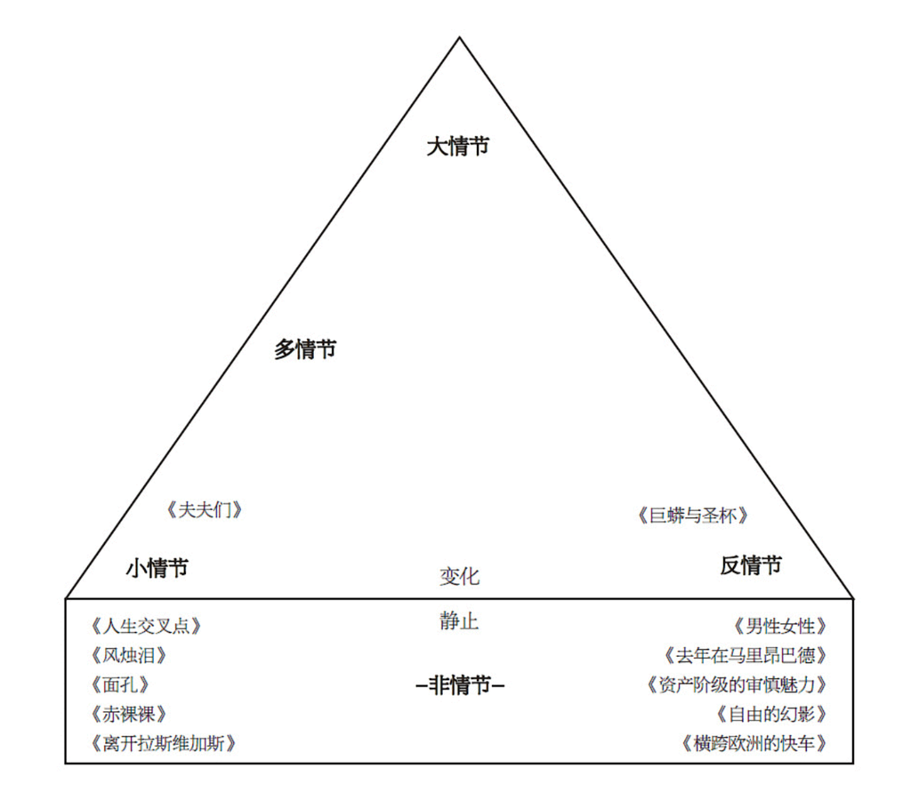

*故事三角*

*多情节影片常常经典性不足，最小主义有余* *当影片中插入拟纪录片场景时，总体“现实”便成为问题，成为准反情节*

8. **变化VS静止**
   - 非情节中，故事保持静止状态，没有变化弧光。故事要么是对生活的逼真刻画，要么是荒诞刻画。
   - 非情节没有讲述故事。但我们能从中得到一种清醒的认识，并寄希望于我们内心深处的什么东西会有所改变。

## 故事设计的政治学

*审美的政治考虑、电影节和电影奖的政治考虑、艺术成功和商业成功相博弈的政治考虑*

**1.好莱坞电影&欧洲电影**

- 好莱坞电影
  - 特效片以及滑稽剧和言情片
  - 愚蠢的乐观：仰仗于大情节；基本是正面结局
  - 常出于商业考虑而强加光明的尾巴
  - 故事牵强，陈词滥调：特效和惊险动作
- 欧洲电影
  - 寥若晨星的优秀影片
  - 美丽的悲观：静态的、非情节的刻板故事或负面结局的极端小情节和反情节；表达变化的无益、无畏甚至毁灭性
  - 为时髦而沉湎于生活的阴暗面
  - 故事单薄，有所欠缺：信息法（对白、自白）和感官刺激（花哨的制作、影音）